# Project 1:Write Up

Likhitha, Paulina, Shrihan

2023-10-25

## Introduction

### Research Topic

The aim of the project was to identify areas of vulnerability for different demographic groups at the census tract level by examining trends in the variables comprising the Social Vulnerability Index (SVI) created by the CDC. SMART questions were identified to narrow the scope of the project. The project sought to address a series of questions, all attempting to identify if there was any correlation between individual census variables and the compiled Thematic SVI scores, to illuminate any possible underrepresented groups across the indexes.

*1*: Does breaking down the SVI by different demographics, such as elderly populations, minority group populations, sex, income impact the vulnerability scores of the census tracts? *2*: Is there significance in identifying areas of population vulnerability based on different demographics compared to the overall population of each tract? *3*: Do specific demographics’ vulnerability ratings have a higher impact on the overall SVI score of the census tract? Can we visualize the different vulnerability scores based on demographic in an impactful way for public health officials and emergency planners? *4*: With the available data and resources (R scripting and visualizations), is it possible to conduct this analysis within the class project deadlines? *5*: Can we provide relevant/significant findings to public health and emergency planning officials (in terms of emergency response and social justice issues)?

### Social Vulnerability Index (SVI)

According to the [CDC](https://www.atsdr.cdc.gov/placeandhealth/svi/index.html), social vulnerability defines the potential negative effects on communities caused by external stresses on human health. These stresses can be events like natural disasters, disease outbreaks, or human-caused events. To address social vulnerability, the CDC has compiled the SVI as a tool to help public health officials and emergency response planners identify communities that may need support before, during, or after disasters. It is provided at the state, county, and census tract level. It is comprised of 16 census variables. By assessing trends in the variables used to create the SVI, the project will examine how splitting the population by different demographics such as race or age affects each census tract’s vulnerability across the 5 compiled themes. This could help identify if there are systemic injustices or inequities, as well as where different vulnerable groups are located.

## Data Set and Variables

### SVI Data

The SVI is comprised of 5 total SVI calculations: 4 thematic and 1 overall summary composed by the sum of the themes.

**Socioeconomic Status**: `RPL_THEME1` * Below 150% Poverty

- Unemployed
- Housing Cost Burden
- No High School Diploma
- No Health Insurance

**Household Characteristics**: `RPL_THEME2` * Aged 65 & Older

- Aged 17 & Younger
- Civilian with a Disability
- Single-Parent Households
- English Language Proficiency

**Racial & Ethnic Minority Status**:`RPL_THEME3` * Hispanic or Latino (of any race); Black and African American, Not Hispanic or Latino; American Indian and Alaska Native, Not Hispanic or Latino; Asian, Not Hispanic or Latino; Native Hawaiian and Other Pacific Islander, Not Hispanic or Latino; Two or More Races, Not Hispanic or Latino; Other Races, Not Hispanic or Latino

**Housing Type & Transportation**: `RPL_THEME4`

- Multi-Unit Structures
- Mobile Homes
- Crowding
- No Vehicle
- Group Quarters

**Overall**: `RPL_THEMES` * CDC then sums the sums for each theme, orders the tracts, and then calculates overall percentile rankings.

## Clean the Data

**We performed the following steps to clean the SVI dataset**

**Extract the data file**

As mentioned before the dataset was sourced directly from the CDC website. The dataset was downloaded in the form of CSV file and integrated into the project.

```r
SVI_Data <- read.csv("SVI_2020_US.csv")
head(SVI_Data)
```

**Subset the columns**

```r
#selecting the required columns by subset function

Clean_data <- subset(SVI_Data, select = c(ST,STATE,ST_ABBR,STCNTY,COUNTY,FIPS,LOCATION,AREA_SQMI,EPL_POV150,    EPL_UNEMP,  EPL_HBURD,  EPL_NOHSDP, EPL_UNINSUR,    SPL_THEME1, RPL_THEME1, EPL_AGE65,  EPL_AGE17,  EPL_DISABL, EPL_SNGPNT, EPL_LIMENG, SPL_THEME2, RPL_THEME2, EPL_MINRTY, SPL_THEME3, RPL_THEME3, E_MINRTY, EP_HISP, EP_ASIAN, EP_AIAN, EPL_MUNIT,    EPL_MOBILE, EPL_CROWD,  EPL_NOVEH,  EPL_GROUPQ, SPL_THEME4, RPL_THEME4, SPL_THEMES, RPL_THEMES, E_AGE65, EP_POV150, EP_AGE65, EP_NOHSDP
) )

head(Clean_data)
```

**Subset the rows**

Additionally, the dataset comprises of substantial 84,000 rows. Again to tailor our analysis, we opted to narrow our scope to a specific area of interest, so we performed a row subsetting operation to include data exclusively related to California.

```r
CA_SVI <- subset(Clean_data, ST_ABBR == "CA")
```

## Outliers

### RPL_THEME1

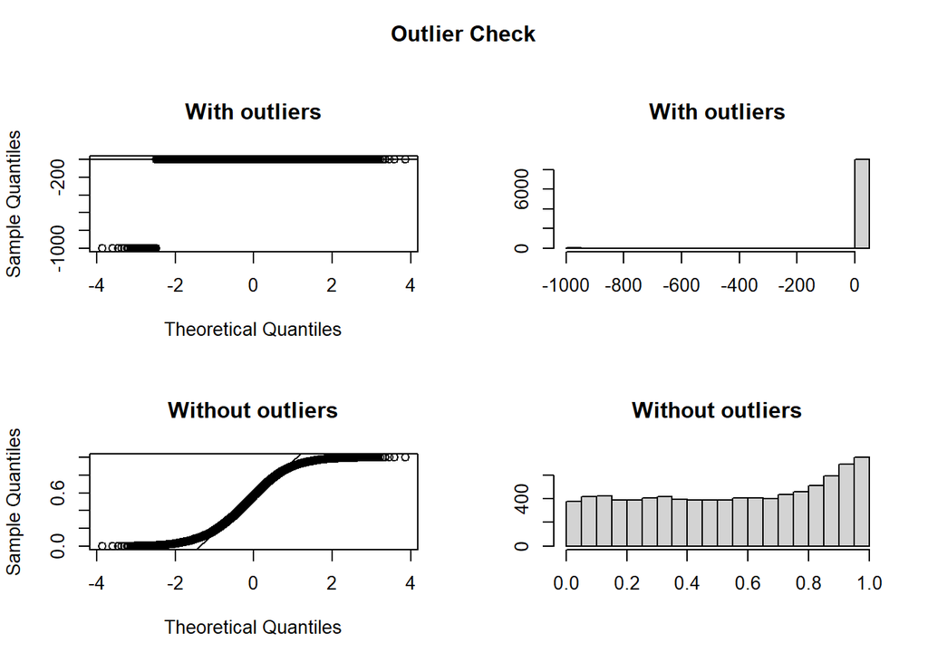

```
## Outliers identified: 58
## Proportion (%) of outliers: 0.6
## Mean of the outliers: -999
## Mean without removing outliers: -5.82
## Mean if we remove outliers: 0.55
## Nothing changed
```

```r
Outliers1 = outlierKD2(CA_SVI, RPL_THEME1, rm = FALSE, qqplt = TRUE)
```

### RPL_THEME2

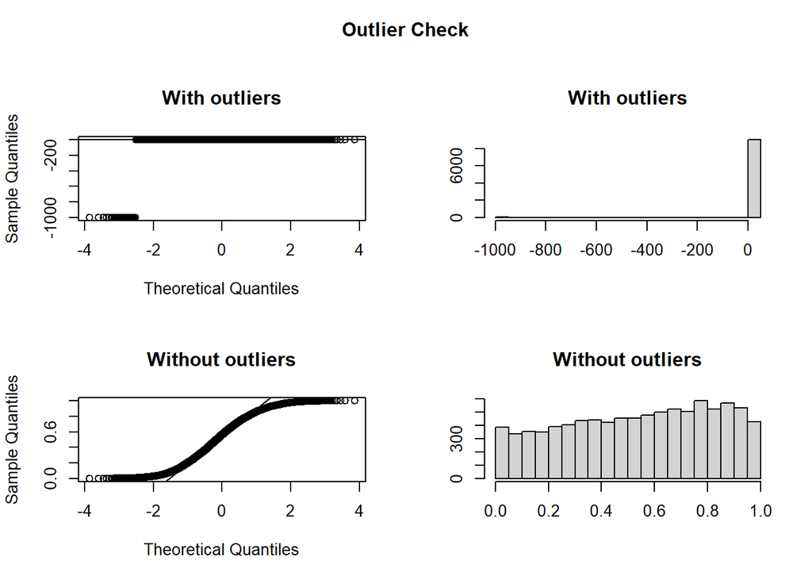

```
## Outliers identified: 54
## Proportion (%) of outliers: 0.6
## Mean of the outliers: -999
## Mean without removing outliers: -5.39
## Mean if we remove outliers: 0.54
## Nothing changed
```

```r
Outliers2 = outlierKD2(CA_SVI, RPL_THEME2, rm = FALSE, qqplt = TRUE)
```

### RPL_THEME3

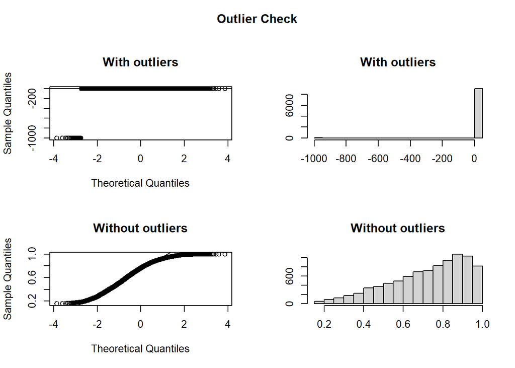

```
## Outliers identified: 67
## Proportion (%) of outliers: 0.7
## Mean of the outliers: -417
## Mean without removing outliers: -2.35
## Mean if we remove outliers: 0.72
## Nothing changed
```

```r
Outliers3 = outlierKD2(CA_SVI, RPL_THEME3, rm = FALSE, qqplt = TRUE)
```

### RPL_THEME4

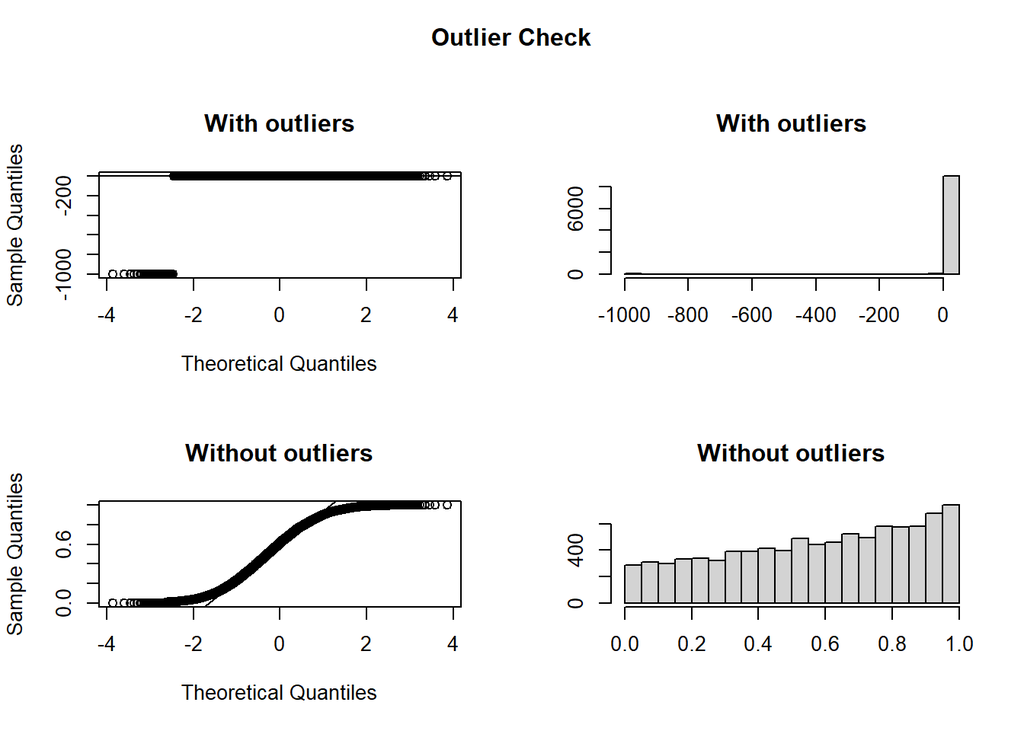

```
## Outliers identified: 63
## Proportion (%) of outliers: 0.7
## Mean of the outliers: -999
## Mean without removing outliers: -6.34
## Mean if we remove outliers: 0.58
## Nothing changed
```

```r
Outliers4 = outlierKD2(CA_SVI, RPL_THEME4, rm = FALSE, qqplt = TRUE)
```

### RPL_THEMES

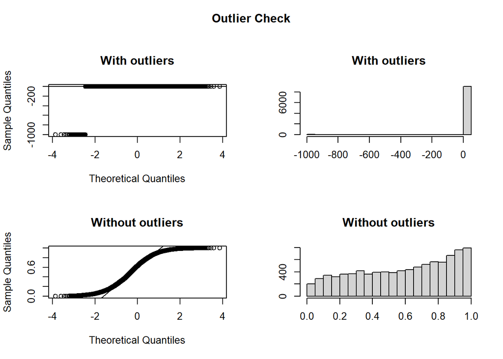

```
## Outliers identified: 65
## Proportion (%) of outliers: 0.7
## Mean of the outliers: -999
## Mean without removing outliers: -6.54
## Mean if we remove outliers: 0.59
## Nothing changed
```

```r
Outliers = outlierKD2(CA_SVI, RPL_THEMES, rm = FALSE, qqplt = TRUE)
```

### Explanation

**RPL_THEMES**

```r
count <- sum(CA_SVI$RPL_THEMES == -999)
count1 <- sum(CA_SVI$RPL_THEME1 == -999)
count2 <- sum(CA_SVI$RPL_THEME2 == -999)
count3 <- sum(CA_SVI$RPL_THEME3 == -999)
count4 <- sum(CA_SVI$RPL_THEME4 == -999)
```

- There are 65 missing values in `RPL_THEMES`
- There are 58 missing values in `RPL_THEME1`
- There are 54 missing values in `RPL_THEME2`
- There are 28 missing values in `RPL_THEME3`
- There are 63 missing values in `RPL_THEME4`

## Data Analysis

### Maps

It is interesting to examine the spatial distribution of this dataset, given that it looks across census tracts, a geographic scale. This portion of the analysis examines the spatial distribution of SVI and demographic variables.

First the data had to be prepped for spatial analysis. *Note, when conducting the spatial join between `ca_tracts` and `CA_SVI`, there were 20 tracts present in `ca_tracts` not identified in `CA_SVI`.*

```r
#Load 2020 Census Tract shapefile for California
ca_tracts <- tracts(state = "CA", year = 2020)

#add 0 to FIPS variable in CA_SVI to merge with ca_tracts (on GEOID)
CA_SVI$FIPS <- paste0("0", CA_SVI$FIPS)

#Join CA_SVI and ca_tracts based on FIPS and GEOID
CA_SVI <- inner_join(CA_SVI, ca_tracts, by = c("FIPS" = "GEOID"))

#for mapping, convert CA_SVI to a Simple Features (map object)
ca_svi_sf <- st_as_sf(CA_SVI)

#remove missing values from our variables:
ca_svi_sf_clean <- subset(ca_svi_sf, RPL_THEME2 != -999)
```

### Histogram

#### Histograms

We harnessed the power of histograms to pinpoint the counties within different California regions that could be particularly vulnerable to the effects of disasters or health crises. Our analysis successfully unveiled the top 10 counties characterized by the highest Social Vulnerability Index (SVI) scores, elevated poverty rates, increased unemployment levels, and a notable population lacking insurance coverage.

##### HISTOGRAM #1

This visualization showcases the counties most susceptible to social vulnerability, highlighting the top 10 counties with the highest mean SVI scores.

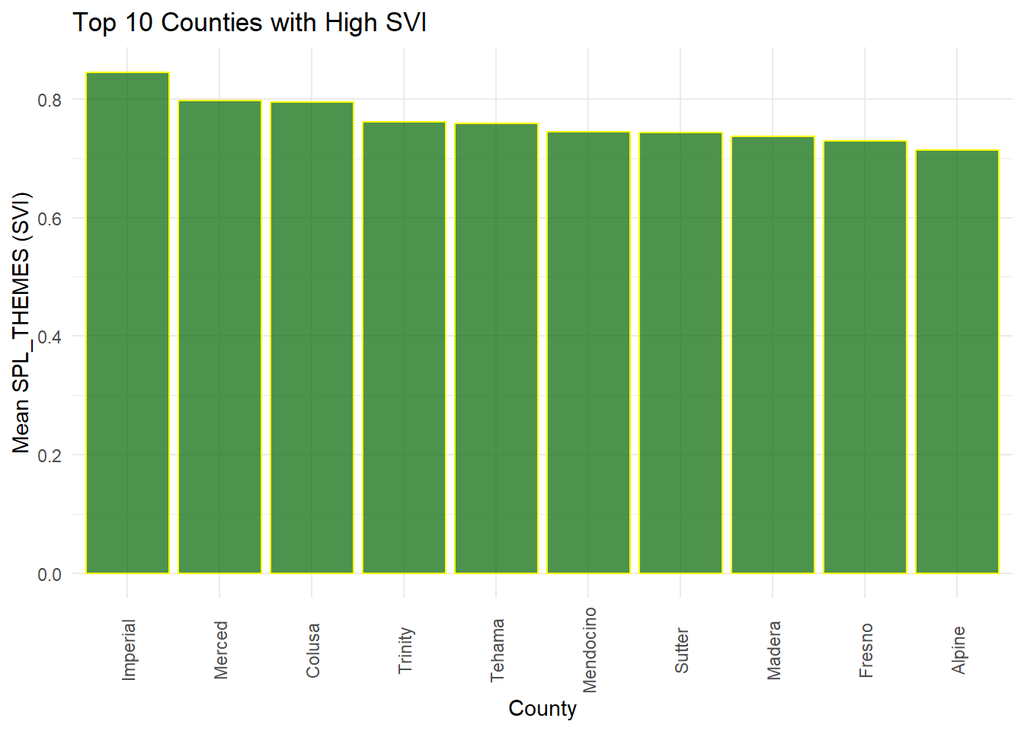

```r
county_svi <- CA_SVI %>%
  group_by(COUNTY) %>%
  summarize(mean_SVI = mean(RPL_THEMES)) %>%
  ungroup()

# Select the top 10 counties with the highest mean SVI
top_10_counties <- county_svi %>%
  top_n(10, wt = mean_SVI)

# Create a histogram of the mean SVI for the top 10 counties
histogram_plot <- ggplot(data = top_10_counties, aes(x = reorder(COUNTY, -mean_SVI), y = mean_SVI)) +
  geom_bar(stat = "identity", fill = "darkgreen", color = "yellow", alpha = 0.7) +

  # Label the axes and add a title
  labs(x = "County", y = "Mean SPL_THEMES (SVI)", title = "Top 10 Counties with High SVI") +

  # Customize the appearance
  theme_minimal() +
  theme(axis.text.x = element_text(angle = 90, vjust = 0.5))  # Rotate x-axis labels for better readability

# Display the histogram
print(histogram_plot)
```

The histogram visualizes the distribution of mean SVI (mean of RPL_THEMES) scores across different counties. The height of each bar represents the mean SVI for a specific county. Higher bar heights indicate higher mean SVI scores. From the histogram its evident that the highest mean SVI in California is > 0.8 (Imperial county)

This histogram serves as a valuable visualization for decision-makers, emergency planners, and policymakers. It highlights the areas that might require special attention and resources to address social vulnerability effectively. Targeting these counties for disaster preparedness, healthcare support, or socioeconomic initiatives can contribute to enhancing resilience and reducing vulnerability.

##### HISTOGRAM #2

The below histogram displays the top 10 counties in California with the highest levels of poverty based on the EPL_POV150 (Percentage of the population living below the poverty line) indicator. These counties are characterized by a significant percentage of their population living below the poverty line, indicating economic vulnerability.

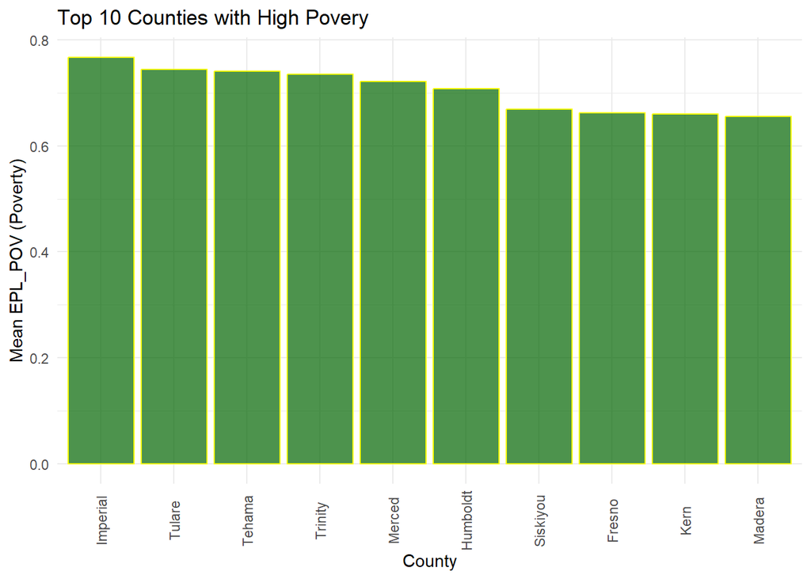

```r
county_svi <- CA_SVI %>%
  group_by(COUNTY) %>%
  summarize(mean_POV = mean(EPL_POV150)) %>%
  ungroup()

# Select the top 10 counties with the highest mean EPL_POV
top_10_counties_POV150 <- county_svi %>%
  top_n(10, wt = mean_POV)

histogram_plot <- ggplot(data = top_10_counties_POV150, aes(x = reorder(COUNTY, -mean_POV), y = mean_POV)) +
  geom_bar(stat = "identity", fill = "darkgreen", color = "yellow", alpha = 0.7) +

  # Label the axes and add a title
  labs(x = "County", y = "Mean EPL_POV (Poverty)", title = "Top 10 Counties with High Povery") +

  # Customize the appearance
  theme_minimal() +
  theme(axis.text.x = element_text(angle = 90, vjust = 0.5))  # Rotate x-axis labels for better readability

# Display the histogram
print(histogram_plot)
```

The histogram visually represents the distribution of mean EPL_POV150 (Poverty) scores across different counties in California. Each bar in the histogram corresponds to a specific county, and the height of the bar indicates the mean poverty level in that county. Taller bars represent counties with higher mean poverty rates.

This histogram can be a valuable visualization for social planners, and organizations working on poverty alleviation. It identifies areas with the most pressing poverty-related challenges, guiding resource allocation, social support programs, and initiatives aimed at reducing poverty and improving the well-being of residents.

##### HISTOGRAM #3

The below histogram displays the top 10 counties in California with the highest levels of unemployment based on the EPL_UNEMP (Percentage of the population unemployed) indicator. These counties experience a substantial percentage of their population facing unemployment, indicating economic and workforce vulnerability.

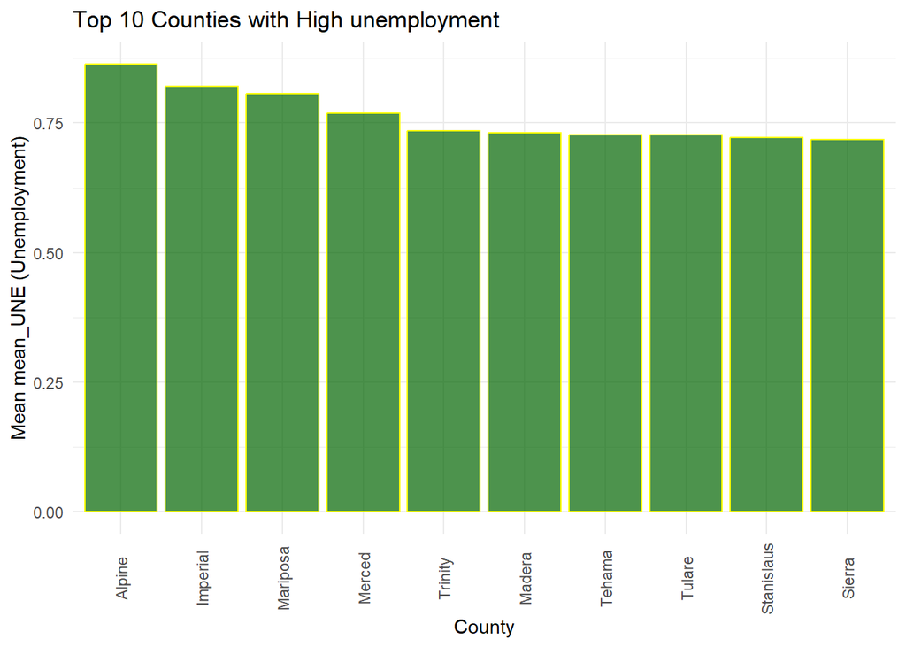

```r
county_svi <- CA_SVI %>%
  group_by(COUNTY) %>%
  summarize(mean_UNE = mean(EPL_UNEMP)) %>%
  ungroup()

# Select the top 10 counties with the highest mean EPL_UNEMP
top_10_counties_UNEMP <- county_svi %>%
  top_n(10, wt = mean_UNE)

histogram_plot <- ggplot(data = top_10_counties_UNEMP, aes(x = reorder(COUNTY, -mean_UNE), y = mean_UNE)) +
  geom_bar(stat = "identity", fill = "darkgreen", color = "yellow", alpha = 0.7) +

  # Label the axes and add a title
  labs(x = "County", y = "Mean mean_UNE (Unemployment)", title = "Top 10 Counties with High unemployment") +

  # Customize the appearance
  theme_minimal() +
  theme(axis.text.x = element_text(angle = 90, vjust = 0.5))  # Rotate x-axis labels for better readability

# Display the histogram
print(histogram_plot)
```

The histogram visually represents the distribution of mean EPL_UNEMP (Unemployment) scores across various counties in California. Each bar in the histogram corresponds to a specific county, and the height of the bar indicates the mean unemployment rate in that county. Taller bars represent counties with higher mean unemployment rates.

This histogram serves as a valuable visualization for workforce development agencies, and organizations involved in employment and economic growth. It highlights regions where unemployment is a significant concern, providing insights for resource allocation, job creation initiatives, and unemployment reduction programs.

##### HISTOGRAM #4

The below histogram highlights the top 10 counties in California with the highest levels of people without health insurance, as measured by the EPL_UNINSUR (Percentage of the population without health insurance) indicator. These counties have a significant portion of their population lacking health insurance coverage, indicating potential vulnerabilities in accessing healthcare services.

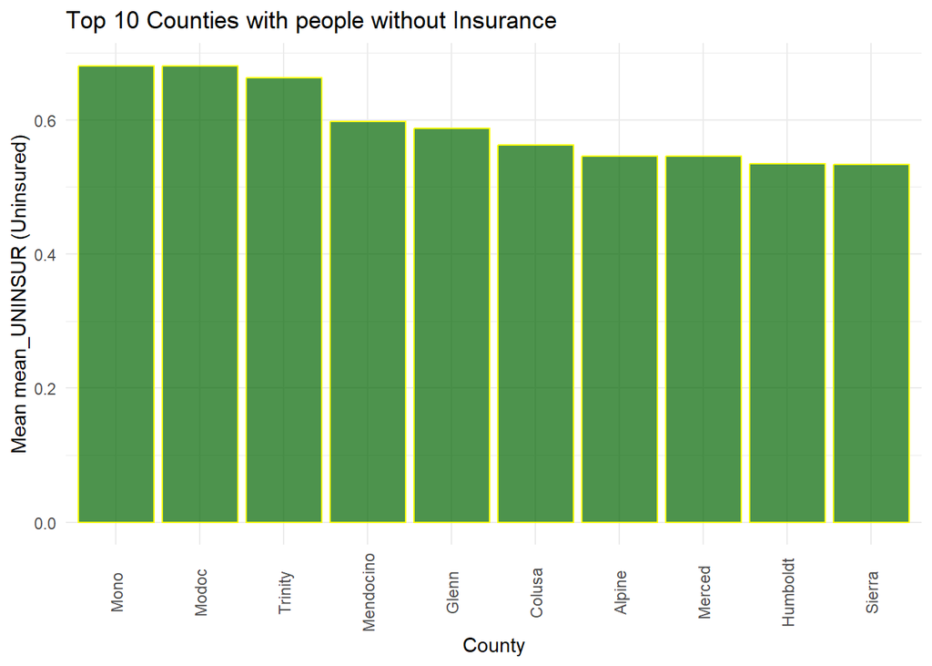

```r
county_svi <- CA_SVI %>%
  group_by(COUNTY) %>%
  summarize(mean_UNINSUR = mean(EPL_UNINSUR)) %>%
  ungroup()

# Select the top 10 counties with the highest mean mean_UNINSUR
top_10_counties_UNINSUR <- county_svi %>%
  top_n(10, wt = mean_UNINSUR)

histogram_plot <- ggplot(data = top_10_counties_UNINSUR, aes(x = reorder(COUNTY, -mean_UNINSUR), y = mean_UNINSUR)) +
  geom_bar(stat = "identity", fill = "darkgreen", color = "yellow", alpha = 0.7) +

  # Label the axes and add a title
  labs(x = "County", y = "Mean mean_UNINSUR (Uninsured)", title = "Top 10 Counties with people without Insurance") +

  # Customize the appearance
  theme_minimal() +
  theme(axis.text.x = element_text(angle = 90, vjust = 0.5))  # Rotate x-axis labels for better readability

# Display the histogram
print(histogram_plot)
```

The histogram visually represents the distribution of mean EPL_UNINSUR (Uninsured) scores across various counties in California. Each bar in the histogram corresponds to a specific county, and the height of the bar indicates the mean percentage of the population without health insurance in that county. Taller bars represent counties with a higher percentage of uninsured residents.

This histogram provides valuable insights for healthcare providers, and organizations working to improve access to healthcare services. It highlights regions where a substantial population lacks health insurance, guiding initiatives for expanding healthcare coverage and addressing healthcare disparities.

### Scatterplots

#### Scatterplots

##### Scatterplots #1

A scatterplot comparing “RPL_THEMES” to “RPL_THEME1” offers valuable insights into the interplay of various social vulnerability factors. By examining this relationship, we can uncover how “Socioeconomic Status” (RPL_THEME1) influences the broader composite of social vulnerability (RPL_THEMES).

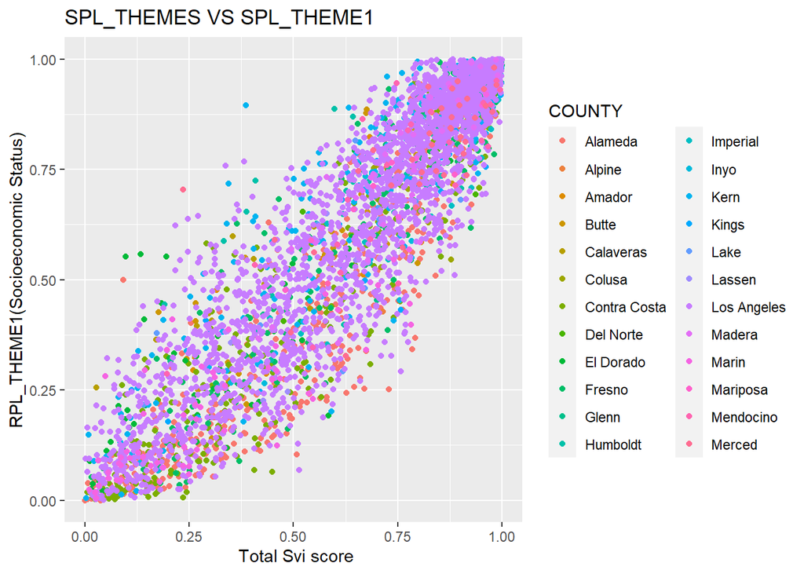

```r
CA_SVI <- subset(CA_SVI,  RPL_THEME1!= -999 )
CA_SVI <- subset(CA_SVI,  RPL_THEMES!= -999 )
CA_SVI<-subset(head(CA_SVI,4000))
CA_SVI1 <- subset(head(CA_SVI, 8000))




ggplot(CA_SVI, aes(x = RPL_THEMES, y = RPL_THEME1, color=COUNTY)) +
  geom_point() +
  labs(x = " Total Svi score", y = "RPL_THEME1(Socioeconomic Status)") +
  ggtitle("SPL_THEMES VS SPL_THEME1")
```

The scatter plot shows the relationship between the total SVI score (RPL_THEMES) and the socioeconomic status theme score (RPL_THEME1). The graph is colored by county, which allows us to see how the relationship between the two variables varies across different counties in California.

However, there is also some variation in the relationship between the two variables across different counties. For example, some counties with high socioeconomic status (like LA) scores have relatively low total SVI scores, and vice versa. This suggests that there are other factors, in addition to socioeconomic status, that also contribute to the overall SVI score.

##### Scatterplots #2

“RPL_THEMES” vs “EP_AGE65” provides insights into the influence of age demographics on social vulnerability. This analysis helps us understand how the percentage of the population aged 65 and older affects overall social vulnerability, contributing to more informed community resilience and public health planning.

[figure not shown]

```r
library(ggplot2)


CA_SVI <- subset(CA_SVI,  EP_AGE65!= -999 )
CA_SVI <- subset(CA_SVI,  RPL_THEMES!= -999 )



ggplot(CA_SVI, aes(y = EP_AGE65, x = RPL_THEMES)) +
  geom_point(color='red') +
  labs(x = "Percent of population Age 65 or older", x = "RPL_THEMES(Total SVI)") +
  ggtitle("Social Vulnerability vs Hispanic Population")
```

This graph shows the relationship between total SVI score (RPL_THEMES) and percent of population Age 65 or Older (EP_AGE65). In this scatter plot, data points are mostly concentrated along the x-axis (RPL_THEMES). This concentration near the x-axis suggests that there is little variation in the Total SVI (RPL_THEMES) with respect to the percentage of the population aged 65 or older (EP_AGE65).

The horizontal distribution of data points indicates that there is no strong linear correlation between EP_AGE65 and RPL_THEMES. In other words, changes in the percentage of the population aged 65 or older do not appear to correspond to significant changes in the Total SVI score.

This could indicate that other factors or variables may be influencing the Total SVI more significantly than age alone. The relationship might be more complex or influenced by multiple factors.

The lack of a clear linear relationship between age and Total SVI suggests that age alone may not be a strong predictor of social vulnerability in this context. This insight is valuable for public health officials and emergency planners, as it may guide resource allocation and intervention strategies that consider a broader set of determinants.

##### Scatterplots #3

“EP_NOHSDP” vs “RPL_THEME3” unveils the dynamic link between education and social vulnerability. This analysis elucidates how the percentage of the population with no high school diploma influences vulnerability related to “Race and Ethnicity” (RPL_THEME3)

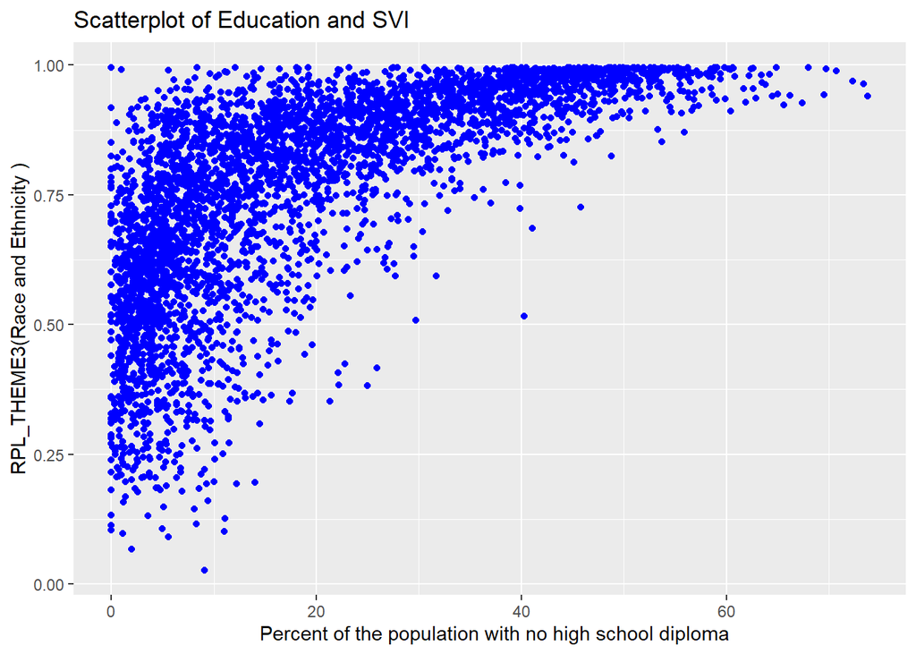

```r
library(ggplot2)


CA_SVI <- subset(CA_SVI,  EP_NOHSDP!= -999 )
CA_SVI <- subset(CA_SVI,  RPL_THEME3!= -999 )


ggplot(CA_SVI, aes(x = EP_NOHSDP, y = RPL_THEME3, color=COUNTY)) +
  geom_point(color='blue') +
  labs(x = "  Percent of the population with no high school diploma", y = "RPL_THEME3(Race and Ethnicity )") +
  ggtitle("Scatterplot of Education and SVI")
```

The threshold effect implies that a specific level of education attainment (or lack thereof) may significantly influence the social vulnerability as measured by RPL_THEME3. It’s essential to understand the reasons behind this threshold and how it relates to the SVI’s focus on “Race and Ethnicity.”

##### Scatterplots #4

“EP_HISP” vs “RPL_THEME1” uncovers the influence of the Hispanic population on socioeconomic vulnerability. This analysis provides critical insights into how changes in the percentage of Hispanic residents impact the broader socioeconomic aspect of social vulnerability.

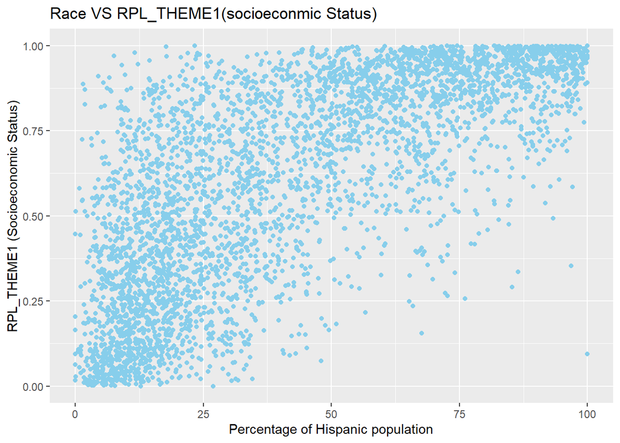

```r
library(ggplot2)

CA_SVI <- subset(CA_SVI, EP_HISP != -999)
CA_SVI <- subset(CA_SVI, RPL_THEME1 != -999)
ggplot(CA_SVI, aes(x = EP_HISP, y = RPL_THEME1)) +
  geom_point(color = 'skyblue') +
  labs(x = "Percentage of Hispanic population", y = "RPL_THEME1 (Socioeconomic Status)") +ggtitle("Race VS RPL_THEME1(socioeconmic Status)")
```

Beyond the 65% mark of EP_HISP, there is a noticeable shift in the data distribution. Most data points cluster between SVI of 0.75 and 1, indicating a more consistent relationship between EP_HISP and RPL_THEME1.

This pattern hints at a potential threshold effect, where the Hispanic population percentage may not significantly impact socioeconomic status (RPL_THEME1) below a certain level, but above this threshold, there is a more consistent impact.

For policymakers and public health officials, this graph suggests that interventions and policies may have a more pronounced effect on socio-economic status if the Hispanic population is above 65%.

### Correlation Heatmap

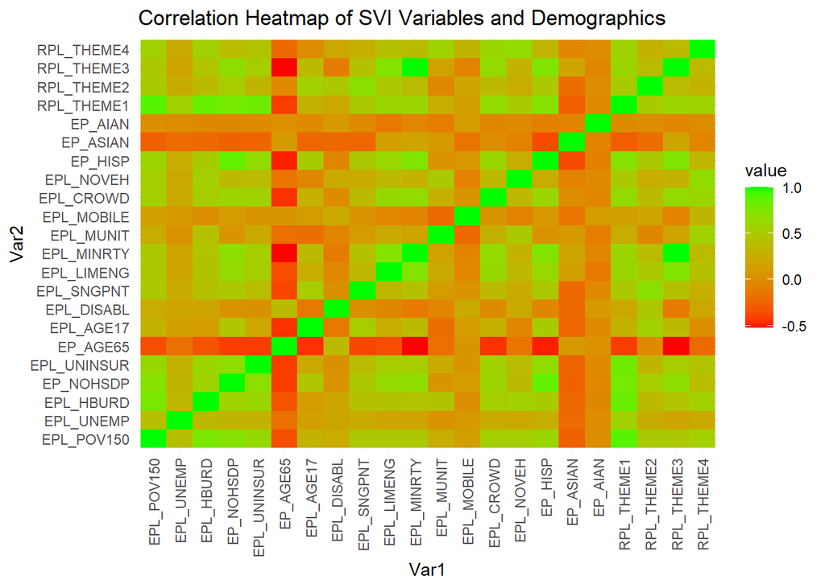

```r
library(dplyr)
# creating correlation matrix
correlation_matrix <- cor(CA_SVI[, c("EPL_POV150", "EPL_UNEMP", "EPL_HBURD", "EP_NOHSDP", "EPL_UNINSUR","EP_AGE65", "EPL_AGE17", "EPL_DISABL", "EPL_SNGPNT", "EPL_LIMENG","EPL_MINRTY", "EPL_MUNIT", "EPL_MOBILE", "EPL_CROWD", "EPL_NOVEH","EP_HISP", "EP_ASIAN", "EP_AIAN","RPL_THEME1", "RPL_THEME2", "RPL_THEME3", "RPL_THEME4")])

correlation_melted <- melt(correlation_matrix)

ggplot(correlation_melted, aes(Var1, Var2, fill = value)) +
  geom_tile() +
  scale_fill_gradient(low = "red", high = "green") +
  theme_minimal() +
  theme(axis.text.x = element_text(angle = 90, vjust = 0.5, hjust=1)) + # Rotate x-axis labels
  labs(title = "Correlation Heatmap of SVI Variables and Demographics")
```

The correlation matrix shows the strength and direction of the relationship between each pair of variables. 1 indicates a perfect positive correlation (Green), a correlation coefficient of -1 indicates a perfect negative correlation (RED), and a correlation coefficient of 0 indicates no correlation (Orange).

There are also some strong negative correlations between some of the variables. For example, AGE_65 is negatively correlated with RPL_THEME1 and RPL_THEME3. The negative correlation suggests that there is an inverse relationship between the percentage of elderly residents and the socio-economic status (RPL_THEME1) and the vulnerability related to race and ethnicity (RPL_THEME3). As the elderly population increases, these aspects of social vulnerability tend to decrease.

EP_ASIAN is litte negatively correlated with RPL_THEME1 and RPL_THEME2. This suggests that as the percentage of the Asian population (EP_ASIAN) increases in a particular area, the RPL_THEME1 and RPL_THEME2 scores tend to decrease.

Like the previous scenario with the elderly population, a higher percentage of Asian residents may act as protective factors against certain social vulnerabilities. This could be due to factors such as economic stability, community support, and educational attainment.

## Future Work

**Aggregate data by county/regions**

**Find spatial autocorrelation of demographic variables**

**Find correlation with other datasets**

Working with the Social Vulnerability Index (SVI) dataset and finding correlations with other datasets can provide valuable insights into social vulnerability factors and their relationships with various other factors. A few of the datasets that we could work on with the SVI dataset are: COVID-19 dataset, the Natural Disasters dataset related to wildfire and earthquake, Economic and Income Datasets etc

**Predict which communities are vulnerable after natural disaster/disease outbreak**

We could use the SVI and predictive modelling techinques in disaster preparedness and response, through this we can better allocate resources, save lives, and reduce the impact of disasters and disease outbreaks on vulnerable communities. Additionally, this approach can help us to prioritize interventions and support the goal of achieving equitable disaster resilience.

**Predict future SVI across themes based on projected demographic data**

We could use the SVI dataset from previous years to build a predictive model that can be used to determine the SVI score for different regions.